# octave2

**korreláció** változók szórásával normalizált kovariancia, értéke $[-1,1]$ között  
$\displaystyle \rho_{xy}^{2}=\frac{s_{xy}^{2}}{\sigma_{x}\sigma_{y}}$  
két változó közötti *lineáris kapcsolat erősségét* jellemzi

```
ans = -- cov(x,y) 6(x)6(y) corr(x,y)
ans = a) 0.0136078 1.00116 0.0135921
ans = b) 2.58361 2.58361 1
ans = c) 2.54661 2.82729 0.900726
ans = d) -2.52545 2.80234 -0.901196
```

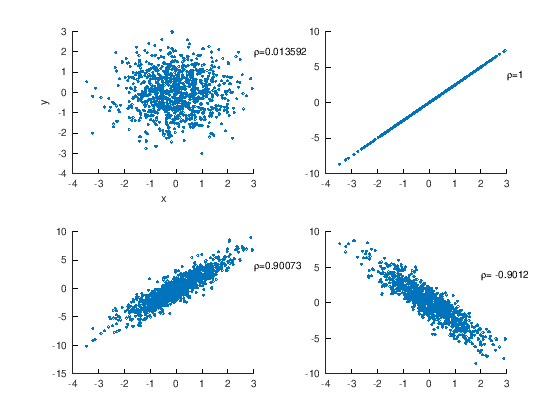

```matlab
format short
sprintf("-- %s %s %s","cov(x,y)","6(x)6(y)","corr(x,y)")
#a) véletlen számok
x = randn(1000,1); # standard normáleloszlásnál szinte minden adat [-3,+3] közé kerül, lásd ábrák
y = randn(1000,1);

sprintf("a) %d %d %d",cov(x,y),std(x)*std(y),corr(x,y))
# csillagos égbolt: nem korrelál,nincs lineáris tendencia

subplot (2, 2, 1)
scatter(x,y);ylabel ("y");xlabel ("x")
text(3,2,['\rho=' num2str(corr(x,y))])

#b)
y = 2.5*x; #tökéletes lineáris kapcsolat

sprintf("b) %d %d %d",cov(x,y),std(x)*std(y),corr(x,y))


subplot (2, 2, 2)
scatter(x,y)
text(3,4,['\rho=' num2str(corr(x,y))])

#c) lineáris kapcsolat + zaj(mérési hiba)
for i=1:1000 y(i) = 2.5*x(i)+1.2*randn(); endfor;

sprintf("c) %d %d %d",cov(x,y),std(x)*std(y),corr(x,y))

subplot (2, 2, 3)
scatter(x,y)
text(3,4,['\rho=' num2str(corr(x,y))])

#d) negatív korreláció
for i=1:1000 y(i) = -2.5*x(i)+1.2*randn(); endfor;

sprintf("d) %d %d %d",cov(x,y),std(x)*std(y),corr(x,y))

subplot (2, 2, 4)
scatter(x,y)
text(2,4,['\rho= ' num2str(corr(x,y))])
```

**mátrixra alkalmazva**: oszlopok között számolt kovariancia, korreláció  
a kovariancia mátrix (CV) szimmetrikus, diagonálisban (oszlopindex = sorindexek) varianciák

$\tiny CV=\tiny\begin{bmatrix} \mathrm{Cov}(1,1)=\mathrm{Var}(1)&\mathrm{Cov}(1,2) &\mathrm{Cov}(1,3) \\ \mathrm{Cov}(2,1) &\mathrm{Cov}(2,2)=\mathrm{Var}(2) &\mathrm{Cov}(2,3) \\ \mathrm{Cov}(3,1)&\mathrm{Cov}(3,2) &\mathrm{Cov}(3,3)=\mathrm{Var}(3) \end{bmatrix}$

```matlab
clear
D=randn(10,3);
D(:,2)=D(:,1)*2.5;
for i=1:10 D(i,3) = D(i,1)*2.5+randn()*2.0; endfor;
cov(D)
corr(D)

D=randn(10,3);
St = zscore(D);
cov_St = cov(St)
corr_D = corr(D)
disp("standardizált kovarianciája azonos az eredeti korrelációjával")
```

```
ans =

    1.2000    3.0001    3.4885
    3.0001    7.5002    8.7213
    3.4885    8.7213   13.4784

ans =

   1.00000   1.00000   0.86741
   1.00000   1.00000   0.86741
   0.86741   0.86741   1.00000

cov_St =

   1.000000  -0.299821   0.075302
  -0.299821   1.000000  -0.111788
   0.075302  -0.111788   1.000000

corr_D =

   1.000000  -0.299821   0.075302
  -0.299821   1.000000  -0.111788
   0.075302  -0.111788   1.000000

standardizált kovarianciája azonos az eredeti korrelációjával
```

```matlab
# Mátrixműveletek
A=[1,2;3,4]  #2×2
B=randn(2,2); #2×2
C=randn(2,3); #2×3
A' #transzponálás

#mátrixszorzás
A*B;  #2×2 * 2×2 -> 2×2
C*A  #2×3 * 2×2 -/>
A*C; #2×2 * 2×3 -> 2×3
C'*A; #3×2 * 2×2 -> 3×2
```

```
A =

   1   2
   3   4

ans =

   1   3
   2   4

error: operator *: nonconformant arguments (op1 is 2x3, op2 is 2x2)
```

```matlab
A=[1,2;3,4]
B=[4,5;6,7]
A*B  # mátrixszorzás
A.*B # kétmátrixot elemenként szorzunk

A = rand(4,4) ;
A(:,4) = 2*A(:,1)-A(:,2)+0.5*A(:,3); # 4. oszlop lineáris kombinációja az első három oszlopnak -> det zérus lesz
det(A)
```

```
A =

   1   2
   3   4

B =

   4   5
   6   7

ans =

   16   19
   36   43

ans =

    4   10
   18   28

ans = 0
```

**Sajátértékegyenlet, sajátértékprobléma** $\displaystyle\underline{\underline{A}}\;\boldsymbol{v}=\lambda\boldsymbol{v}\quad\quad$ $\boldsymbol{v}$ sajátvektor, $\lambda$ sajátérték

geometriai értelmezés: lineáris transzformáció, $\underline{\underline{A}}$ transzformációs mátrixszal transzformálva $\underline{v}$ vektort, az $\lambda$-szorosára változik  
transzformáció pl. nyújtás, forgatás, tükrözés, nyírás  
kvantummechanika: időfüggetlen Schrödinger: $H\Psi=E\Psi$  
$H$ Hamilton mátrix  
$\Psi$ rendszer állapotfüggvénye (hullámfüggvény, sajátfüggvény)  
$E$ energiasajátértékek mátrixa

```matlab
A = [5 0; 0 5] #nyújtás
[vA,eA]=eig(A) #vA: 2 sajátvektor a két oszlopban
               #eA: diagonális sajátértékmátrix, sajátértékek a főátlóban
v1 = vA(:,1);
e1 = eA(1,1);
#A*v1 = e1*v1
A*v1
e1*v1


B=eye(2)  #2×2 egységmátrix, eye~identity
trace(A)  #főátló elemeinek összege (trace, spur, nyom)
```

```
A =

   5   0
   0   5

vA =

   1   0
   0   1

eA =

Diagonal Matrix

   5   0
   0   5

ans =

   5
   0

ans =

   5
   0

B =

Diagonal Matrix

   1   0
   0   1

ans =  10
```

```matlab
vec(A)   #mátrix oszlopait egymásra pakolja
sqrtm(A)*sqrtm(A) # mátrix négyzetgyöke: sqrtm(A)
                  # sqrtm(A)*sqrtm(A) = A
                  # =/=sqrt(A)
A^(1/3)  # mátrix hatványozása
expm(A)  # Taylor sorként definiálva
```

```
ans =

   5
   0
   0
   5

ans =

   5.00000   0.00000
   0.00000   5.00000

ans =

   1.70998   0.00000
   0.00000   1.70998

ans =

   148.41316     0.00000
     0.00000   148.41316
```

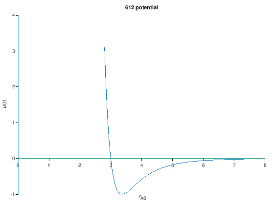

```matlab
#Lennard-Jones potenciál
function u=lj(r) u=4*1*(3**12/r**12-3**6/r**6); endfunction;

#for i=1:10 v(i)=i*0.5+2.3;u(i)=f(v(i));endfor;
r = 2.8:0.01:7.3;
u = arrayfun(@lj,r);

plot(r,u);
set(gca, "xaxislocation", "origin");
set(gca, "yaxislocation", "origin");
box off;
xlim ([0, 8]);
title ("612 potential");xlabel ('{\it r}_{AB}');ylabel ('{\it u}({\itr})');
```

```matlab
fsolve(@lj,2.4) # legközelebbi zérushely meghatározása 2.4 induló érték mellett
fsolve(@lj,3.2) # 3.2 induló érték
fsolve(@lj,4)
lj(33.805)
fzero(@lj,[2,4]) # fzero intervallumon belül keres zérushelyet
fminunc(@lj,3)   # min unconditional, megszorítási feltétel nélkül minimumkeresés, kezdőértéket adunk
fminbnd(@lj,2,4) # f min bound 2 és 4 közötti intervallumon keres minimumot
```

```
ans =  3.0000
ans =  3.0000
ans =  33.805
ans =   -1.9539e-06
ans =  3
ans =  3.3674
ans =  3.3674
```